# Coursera Capstone EDA - Report #1

JRB

November 26, 2017

## Introduction

This report presents a summary of findings from an exploratory analysis of the twitter data files provided for the captsone project. The goal of the exploratory data anlysis is to highlight interesting characteristics of the data that could be used to inform our modelling. The analysis has been performed on a sample of 20,000 lines from the twitter corpus.  
##Data Aquistion

We are downloading and unziping the zip file provided by Coursera. We are also downloading a list of profanities to be used later to clean up the data set. We then proceed to create a data frame corp, which contains one observation per line of text and each observation as three variables:

- *corp*: the origin of the text (twitter, news or blogs)
- *line*: line number
- *text*: the line of text itself from the text

At the end of data acquisition we have a single data frame `corp` that would be used to performe our exploratory data analysis.

## Data Preparation

A few simple steps to prepare the data for analysis.

- Step 1: select the twitter data only
- Step 2: Normalize the case, clean any twitter artifacts (e.g. “rt”) and remove any numbers in the text
- Step 3: tokenize the text by words and eliminateany profanity

This should be enough preparation for our exploratory analysis

## Exploratory Data Analysis

### Summary Statistics

|  | lines | words | distinct |
| --- | --- | --- | --- |
| twitter | 2359384 | 54418 | 19068 |
| blogs | 899103 | 19844 | 6942 |
| news | 1010186 | 22278 | 7793 |

## Part 1: monogram analysis

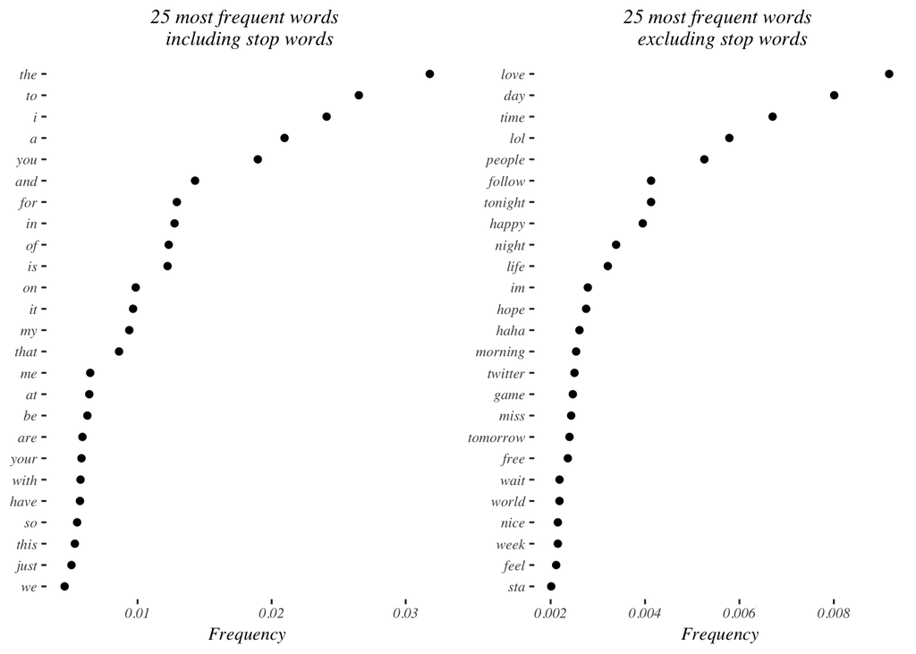

### Word cloud

Word cloud showing the relative importance of the 125 most frequent words in the twiter corpus

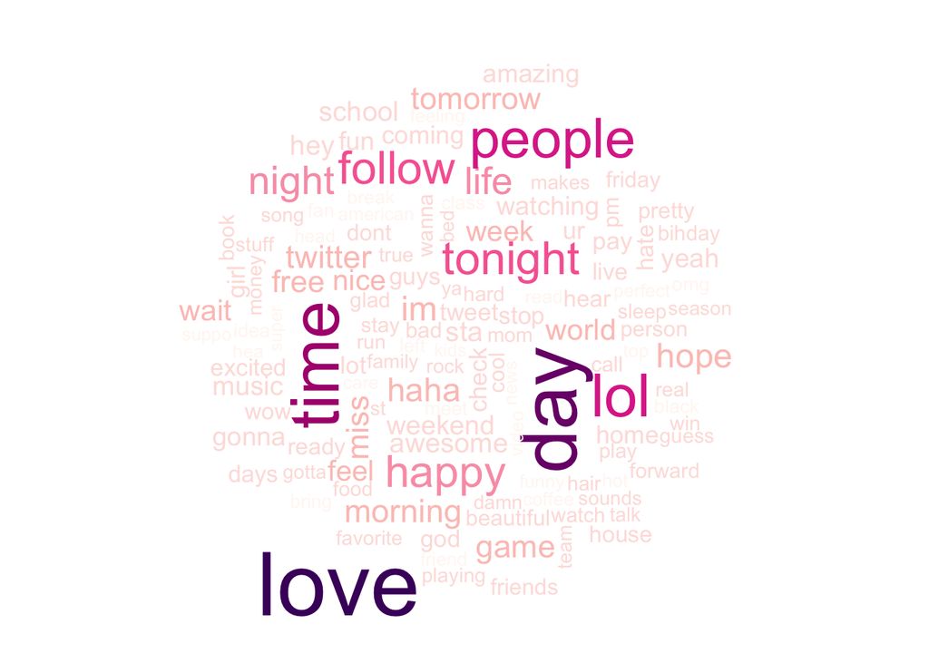

## Part 2: n-gram analysis

### Bigrams analysis

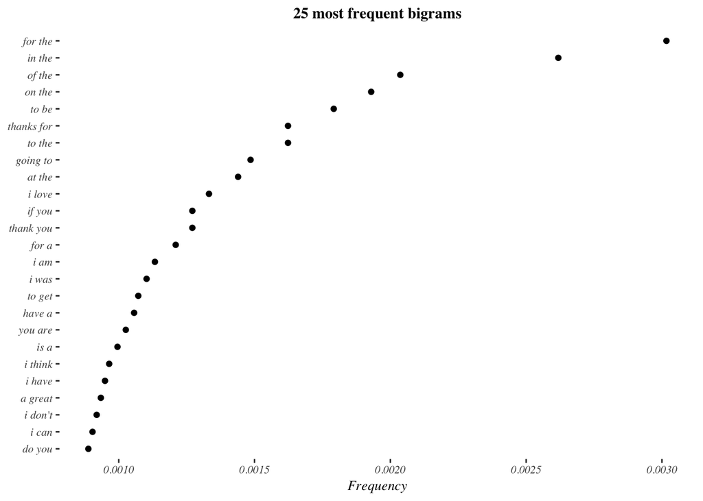

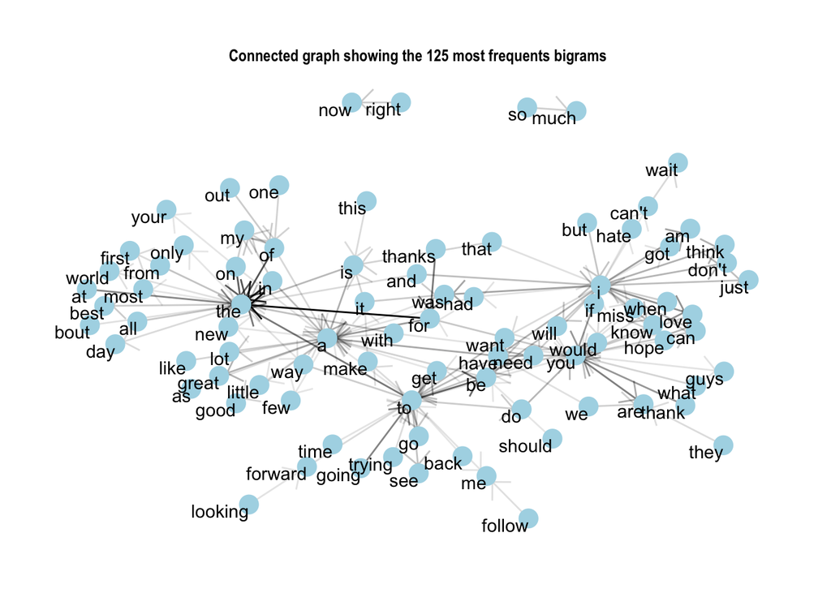

### Trigrams Analysis

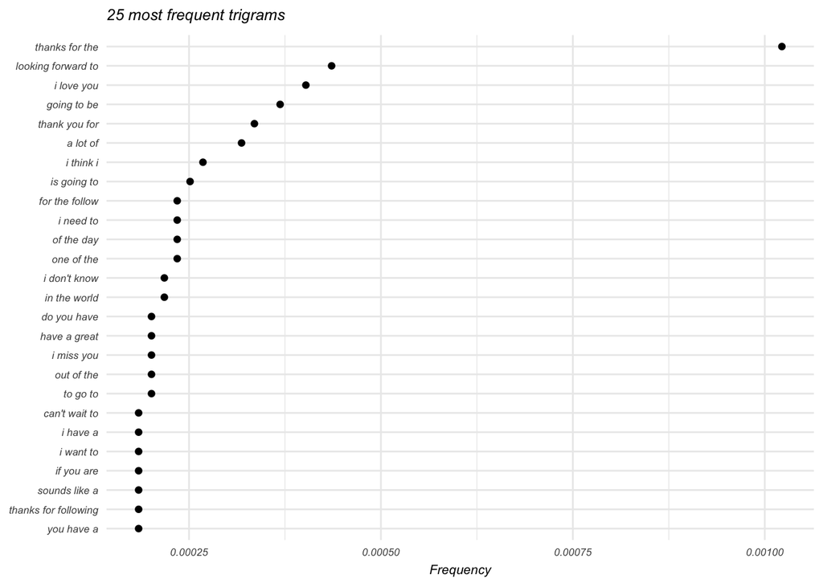

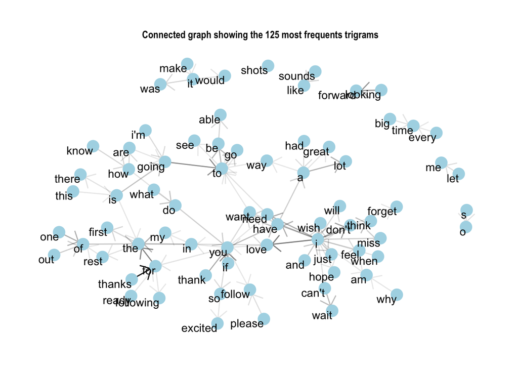

### Dictionary Coverage

As illustrated in the graph below, based on the corpus containing stop words, it will take a dictionary of twitter, 1420 words to cover 80% of the words in the corpus (blue lines) and a twitter, 120 words dictionary to cover 50% of the corpus (red lines).

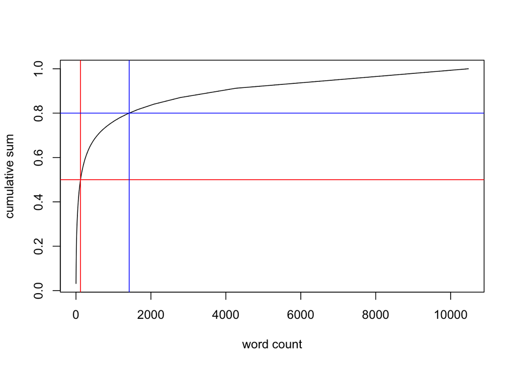

### Conclusions and Next Steps

The analysis shows that a limited dictionary can be used to ensure a relatively large coverage of the corpus. The connected n-grams graph could be used to build the models to asses the probaility of the next word given a starting word. For example, one could imagine a shiny app where the end user enter a word and the application would suggest the most 3 probables words based on the connected graph we could derive from the corpus.

## References:

[How to clean twitter data in r](http://technokarak.com/how-to-clean-the-twitter-data-using-r-twitter-mining-tutorial.html)  
[Text mining in R: the tidy approach](http://tidytextmining.com/)